# Week5 : Tree Based Methods

### Objectives

This homework sheet will help reviewing the basic concepts associated with tree-based methods and provide a basic introduction to the ML workflow using real-world datasets. Please review the lectures, suggested readings, and additional resources *before* getting started on the HW.

**Some questions in this assignment will require you to conduct independent research beyond the material covered in the recorded content.**

The following website has access to the relevant datasets from the recommended textbook: https://book.huihoo.com/introduction-to-statistical-learning/data.html

Marks Distribution

| Question | Marks |
| --- | --- |
| 1 | 3 |
| 2 | 3 |
| 3a | 2 |
| 3b | 2 |
| 3c | 5 |

# Questions

Conceptual

Q1. Draw an example (of your own invention) of a partition of two-dimensional feature space that could result from recursive binary splitting. Your example should contain at least six regions. Draw a decision tree corresponding to this partition. Be sure to label all aspects of your figures, including the regions $R_1$, $R_2$, ... , the cutpoints $t_1$ , $t_2$, ..., and so forth. Please insert your sketch below.

**Please note: You can use Microsoft word / any editor or draw the image by hand, you can upload the image / screenshot to colab file using insert image option in text cell**

ANSWER in the markdown cell

**The images are drawn by hand using the application 'Noteshelf' on a tablet.**

1. There are two features X1 and X2.
2. X1 has cutpoints at t1, t2, t4, t6 whereas X2 has cutpoints at t3 and t5.
3. The 2D feature space is divided 7 regions R1, R2, R3, R4, R5, R6 and R7 based on the binary splits of X1 and X2 at the cutpoints.
4. The corresponding decision tree is given below. It is constructed by performing binary splits on X1 and X2 at their respective cutpoints.

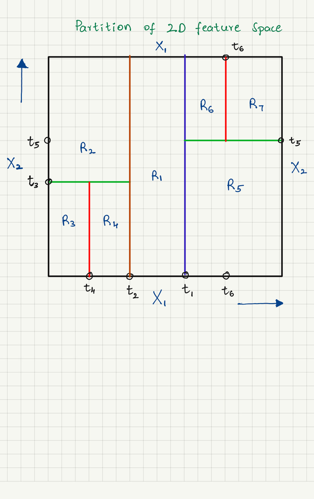

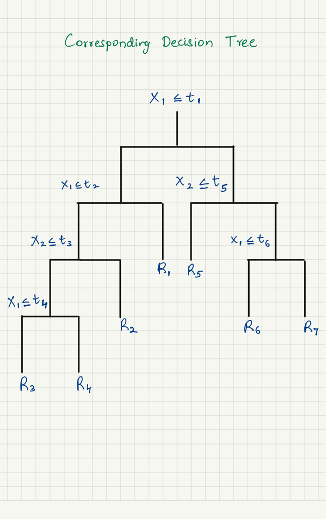

Q2. Suppose we produce ten bootstrapped samples from a data set containing red and green classes. We then apply a classification tree to each bootstrapped sample and, for a specific value of $X$, produce $10$ estimates of $P(Class is Red|X)$:

$0.1$, $0.15$, $0.2$, $0.2$, $0.55$, $0.6$, $0.6$, $0.65$, $0.7$, and $0.75$.

There are two common ways to combine these results together into a single class prediction. One is the majority vote approach , the second approach is to classify based on the average probability. In this example, what is the final classification under each of these two approaches?

ANSWER in the markdown cell

1. We have ten bootstrapped samples with us and a classification tree is fit to each bootstrapped sample. For a given value of X, the 10 estimates of $P(Class is Red|X)$ are $0.1$, $0.15$, $0.2$, $0.2$, $0.55$, $0.6$, $0.6$, $0.65$, $0.7$, and $0.75$.
2. Using the majority vote approach, 6 out of 10 estimates($0.55$, $0.6$, $0.6$, $0.65$, $0.7$, and $0.75$) have $P(Class is Red|X)>0.5$ indicating that the observation X belongs to class 'Red' whereas 4 out of 10 estimates($0.1$, $0.15$, $0.2$, $0.2$) have $P(Class is Red|X)<0.5$ indicating that it belongs to class 'Green'. In majority vote approach, we choose the class with the highest number of votes supporting the class. Therefore, according to majority vote approach, the observation belongs to the class 'Red'.
3. In average probability approach, the observation is classified based on the average of estimates or probabilities. The average probability of $0.1$, $0.15$, $0.2$, $0.2$, $0.55$, $0.6$, $0.6$, $0.65$, $0.7$, and $0.75$ is 0.45(<0.5) which is less than 0.5. This indicates that the observation does not belong to class 'Red'. In otherwords, it belongs to the class 'Green'.
4. Hence, according to majority vote approach the observation X belongs to the class 'Red' whereas according to average probability approach it belongs to the class 'Green'.

# APPLIED

Q3. Apply boosting and random forest to a data set of your choice. Feel free to use any of the datasets from ISLR dataset link provided ( https://book.huihoo.com/introduction-to-statistical-learning/data.html ) to examine any of the questions that were discussed in any of the previous homeworks. Be sure to fit the models on a training set and to evaluate their performance on a test set. How accurate are the results compared to simple methods (e.g. linear or logistic regression models)? Which of these approaches yields the best performance?

#### ANSWER

```python
# import libraries

import numpy as np
import pandas as pd
import matplotlib.pyplot as plt
import seaborn as sns
from sklearn.linear_model import LinearRegression
from sklearn.ensemble import GradientBoostingRegressor, RandomForestRegressor
from sklearn.model_selection import train_test_split
from sklearn.metrics import r2_score, mean_squared_error, accuracy_score
from ISLP import load_data
```

#### a) Read the dataset using function read_csv( ) from pandas library and preprocess the data if required ( check for any missing values etc )

To answer the following questions Auto.csv dataset from week-1 is used. The dataset can be loaded either using pd.read_csv() or using load_data() from ISLP package. For now pd.read_csv() method is used.

```python
org  = pd.read_csv('./Auto.csv')
org.info()
org.head()
```

```
<class 'pandas.core.frame.DataFrame'>
RangeIndex: 397 entries, 0 to 396
Data columns (total 9 columns):
 #   Column        Non-Null Count  Dtype
---  ------        --------------  -----
 0   mpg           397 non-null    float64
 1   cylinders     397 non-null    int64
 2   displacement  397 non-null    float64
 3   horsepower    397 non-null    object
 4   weight        397 non-null    int64
 5   acceleration  397 non-null    float64
 6   year          397 non-null    int64
 7   origin        397 non-null    int64
 8   name          397 non-null    object
dtypes: float64(3), int64(4), object(2)
memory usage: 28.0+ KB
```

|  | mpg | cylinders | displacement | horsepower | weight | acceleration | year | origin | name |
| --- | --- | --- | --- | --- | --- | --- | --- | --- | --- |
| 0 | 18.0 | 8 | 307.0 | 130 | 3504 | 12.0 | 70 | 1 | chevrolet chevelle malibu |
| 1 | 15.0 | 8 | 350.0 | 165 | 3693 | 11.5 | 70 | 1 | buick skylark 320 |
| 2 | 18.0 | 8 | 318.0 | 150 | 3436 | 11.0 | 70 | 1 | plymouth satellite |
| 3 | 16.0 | 8 | 304.0 | 150 | 3433 | 12.0 | 70 | 1 | amc rebel sst |
| 4 | 17.0 | 8 | 302.0 | 140 | 3449 | 10.5 | 70 | 1 | ford torino |

```python
df = org.copy()
print(df['horsepower'].unique()) # There is a '?' present in the horsepower column.

non_num_indices = []
for idx, hp in enumerate(list(df['horsepower'])):

    if hp=='?':
        non_num_indices.append(idx)
        print(f'Index {idx} has a value = {hp}')
non_num_indices
```

```
['130' '165' '150' '140' '198' '220' '215' '225' '190' '170' '160' '95'
 '97' '85' '88' '46' '87' '90' '113' '200' '210' '193' '?' '100' '105'
 '175' '153' '180' '110' '72' '86' '70' '76' '65' '69' '60' '80' '54'
 '208' '155' '112' '92' '145' '137' '158' '167' '94' '107' '230' '49' '75'
 '91' '122' '67' '83' '78' '52' '61' '93' '148' '129' '96' '71' '98' '115'
 '53' '81' '79' '120' '152' '102' '108' '68' '58' '149' '89' '63' '48'
 '66' '139' '103' '125' '133' '138' '135' '142' '77' '62' '132' '84' '64'
 '74' '116' '82']
Index 32 has a value = ?
Index 126 has a value = ?
Index 330 has a value = ?
Index 336 has a value = ?
Index 354 has a value = ?
```

```
[32, 126, 330, 336, 354]
```

```python
# Preprocessing - remove rows from the dataset with '?' value in the horsepower column

df['horsepower'] = pd.to_numeric(df['horsepower'], errors='coerce')

df = df.dropna(subset=['horsepower'])

df.info()
df.head()
```

```
<class 'pandas.core.frame.DataFrame'>
Int64Index: 392 entries, 0 to 396
Data columns (total 9 columns):
 #   Column        Non-Null Count  Dtype
---  ------        --------------  -----
 0   mpg           392 non-null    float64
 1   cylinders     392 non-null    int64
 2   displacement  392 non-null    float64
 3   horsepower    392 non-null    float64
 4   weight        392 non-null    int64
 5   acceleration  392 non-null    float64
 6   year          392 non-null    int64
 7   origin        392 non-null    int64
 8   name          392 non-null    object
dtypes: float64(4), int64(4), object(1)
memory usage: 30.6+ KB
```

|  | mpg | cylinders | displacement | horsepower | weight | acceleration | year | origin | name |
| --- | --- | --- | --- | --- | --- | --- | --- | --- | --- |
| 0 | 18.0 | 8 | 307.0 | 130.0 | 3504 | 12.0 | 70 | 1 | chevrolet chevelle malibu |
| 1 | 15.0 | 8 | 350.0 | 165.0 | 3693 | 11.5 | 70 | 1 | buick skylark 320 |
| 2 | 18.0 | 8 | 318.0 | 150.0 | 3436 | 11.0 | 70 | 1 | plymouth satellite |
| 3 | 16.0 | 8 | 304.0 | 150.0 | 3433 | 12.0 | 70 | 1 | amc rebel sst |
| 4 | 17.0 | 8 | 302.0 | 140.0 | 3449 | 10.5 | 70 | 1 | ford torino |

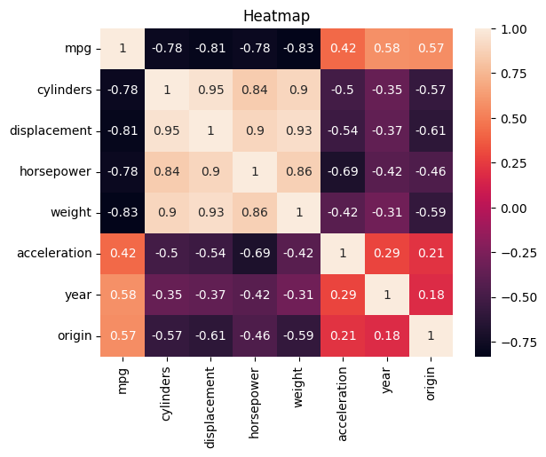

|  | mpg | cylinders | displacement | horsepower | weight | acceleration | year | origin |
| --- | --- | --- | --- | --- | --- | --- | --- | --- |
| mpg | 1.000000 | -0.777618 | -0.805127 | -0.778427 | -0.832244 | 0.423329 | 0.580541 | 0.565209 |
| cylinders | -0.777618 | 1.000000 | 0.950823 | 0.842983 | 0.897527 | -0.504683 | -0.345647 | -0.568932 |
| displacement | -0.805127 | 0.950823 | 1.000000 | 0.897257 | 0.932994 | -0.543800 | -0.369855 | -0.614535 |
| horsepower | -0.778427 | 0.842983 | 0.897257 | 1.000000 | 0.864538 | -0.689196 | -0.416361 | -0.455171 |
| weight | -0.832244 | 0.897527 | 0.932994 | 0.864538 | 1.000000 | -0.416839 | -0.309120 | -0.585005 |
| acceleration | 0.423329 | -0.504683 | -0.543800 | -0.689196 | -0.416839 | 1.000000 | 0.290316 | 0.212746 |
| year | 0.580541 | -0.345647 | -0.369855 | -0.416361 | -0.309120 | 0.290316 | 1.000000 | 0.181528 |
| origin | 0.565209 | -0.568932 | -0.614535 | -0.455171 | -0.585005 | 0.212746 | 0.181528 | 1.000000 |

```python
num_df = df.select_dtypes(include=['float64','int64']) # select numeric columns only

corr_matrix = num_df.corr()


sns.heatmap(corr_matrix,annot=True)
plt.title('Heatmap')
plt.show()
corr_matrix
```

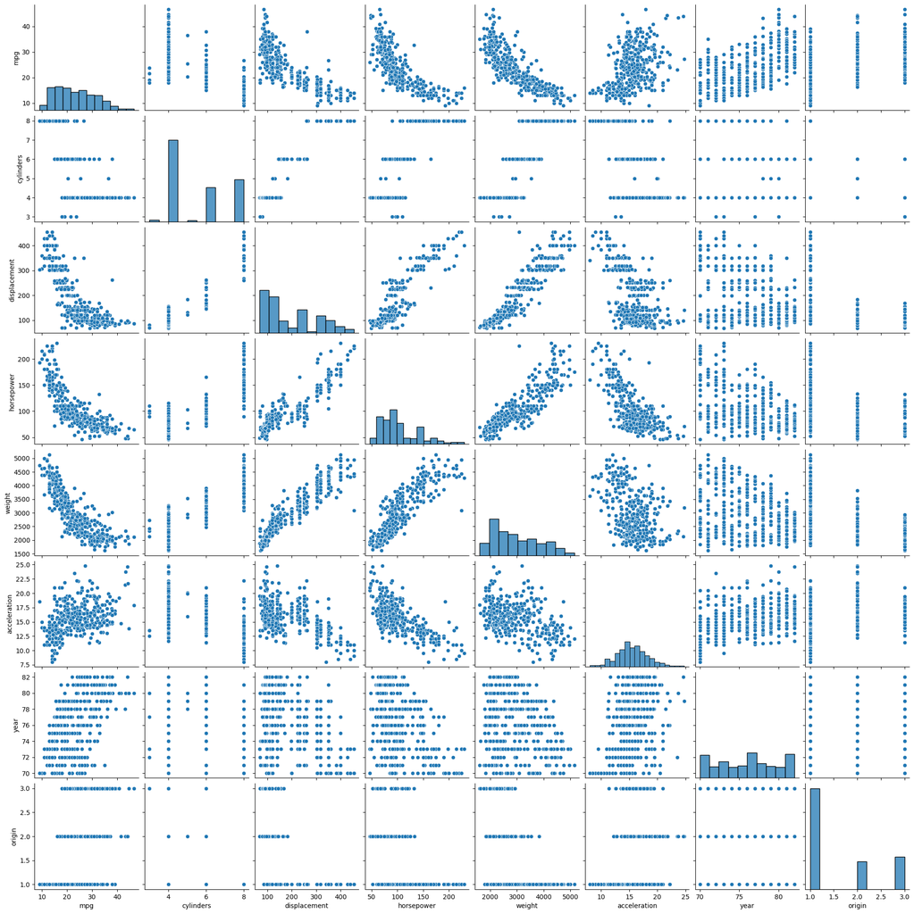

```python
sns.pairplot(df)
plt.show()
```

**We will predict mpg using other variables**

#### b) Split the data into train data and test data ( proportion of train and test data of your choice )

Reference :

https://scikit-learn.org/stable/modules/generated/sklearn.model_selection.train_test_split.html

```python
y = num_df['mpg']
X = num_df.drop(columns=['mpg'])

X_train, X_test, y_train, y_test = train_test_split(X,y, test_size=0.3, random_state=12345)
```

```python
print(X_train.shape, X_test.shape, y_train.shape, y_test.shape)
```

```
(274, 7) (118, 7) (274,) (118,)
```

#### c) Train the data on the below models

i) Linear regression model ii) Gradient boosting model iii) Random forest model

check the train and test r2 score and mention your findings on which model performed better in terms of underfitting / overfitting etc

References:

https://scikit-learn.org/stable/modules/generated/sklearn.linear_model.LinearRegression.html

https://scikit-learn.org/stable/auto_examples/ensemble/plot_gradient_boosting_regression.html#gradient-boosting-regression

https://scikit-learn.org/stable/modules/generated/sklearn.ensemble.RandomForestRegressor.html

https://scikit-learn.org/stable/modules/generated/sklearn.metrics.r2_score.html

**(i) Fitting Linear Regression Model**

```python
lr_model = LinearRegression().fit(X=X_train, y=y_train)

lr_train_r2 = lr_model.score(X_train,y_train)
lr_y_test_pred = lr_model.predict(X_test)
lr_test_r2 = r2_score(y_test,lr_y_test_pred)

lr_train_mse = mean_squared_error(y_train,lr_model.predict(X_train))
lr_test_mse = mean_squared_error(y_test,lr_y_test_pred)

print('R2 score for Linear Regression model on train dataset is',round(lr_train_r2,4),'\n')

print('R2 score for Linear Regression model on test dataset is',round(lr_test_r2,4) ,'\n')

print(f'MSE for Linear Regression model on train dataset = {round(lr_train_mse,4)}\n')
print(f'MSE for Linear Regression model on test dataset = {round(lr_test_mse,4)}\n')
```

```
R2 score for Linear Regression model on train dataset is 0.8276

R2 score for Linear Regression model on test dataset is 0.8005

MSE for Linear Regression model on train dataset = 10.1772

MSE for Linear Regression model on test dataset = 12.6989
```

**(ii) Fitting Gradient Boosting Model**

```python
gb_model = GradientBoostingRegressor().fit(X=X_train,y=y_train)

gb_train_r2 = gb_model.score(X_train,y_train)
gb_y_test_pred = gb_model.predict(X_test)
gb_test_r2 = r2_score(y_test,gb_y_test_pred)

gb_train_mse = mean_squared_error(y_train,gb_model.predict(X_train))
gb_test_mse = mean_squared_error(y_test,gb_y_test_pred)

print('R2 score for Gradient Boosting Regression model on train dataset is',round(gb_train_r2,4),'\n')

print('R2 score for Gradient Boosting Regression model on test dataset is', round(gb_test_r2,4),'\n')

print(f'MSE for Gradient Boosting Regression model on train dataset = {round(gb_train_mse,4)}\n')
print(f'MSE for Gradient Boosting Regression model on test dataset = {round(gb_test_mse,4)}\n')
```

```
R2 score for Gradient Boosting Regression model on train dataset is 0.9767

R2 score for Gradient Boosting Regression model on test dataset is 0.8661

MSE for Gradient Boosting Regression model on train dataset = 1.3732

MSE for Gradient Boosting Regression model on test dataset = 8.5204
```

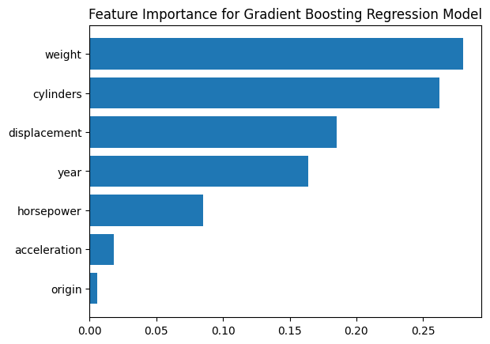

```python
gb_feature_imp = gb_model.feature_importances_
sorted_indices = gb_feature_imp.argsort()[::-1]
sorted_feature_names = [X.columns[i] for i in sorted_indices]
sorted_feat_imp = gb_feature_imp[sorted_indices]

plt.figure()
plt.barh(sorted_feature_names,sorted_feat_imp)
plt.title('Feature Importance for Gradient Boosting Regression Model')
plt.gca().invert_yaxis()
plt.show()
```

**(iii) Random Forest Regressor**

```python
rf_model = RandomForestRegressor().fit(X=X_train,y=y_train)

rf_train_r2 = rf_model.score(X_train,y_train)
rf_y_test_pred = rf_model.predict(X_test)
rf_test_r2 = r2_score(y_test,rf_y_test_pred)

rf_train_mse = mean_squared_error(y_train,rf_model.predict(X_train))
rf_test_mse = mean_squared_error(y_test,rf_y_test_pred)

print('R2 score for Random Forest Regression model on train dataset is',round(rf_train_r2,4),'\n')

print('R2 score for Random Forest Regression model on test dataset is', round(rf_test_r2,4),'\n')

print(f'MSE for Random Forest Regression model on train dataset = {round(rf_train_mse,4)}\n')
print(f'MSE for Random Forest Regression model on test dataset = {round(rf_test_mse,4)}\n')
```

```
R2 score for Random Forest Regression model on train dataset is 0.9806

R2 score for Random Forest Regression model on test dataset is 0.8778

MSE for Random Forest Regression model on train dataset = 1.1478

MSE for Random Forest Regression model on test dataset = 7.7777
```

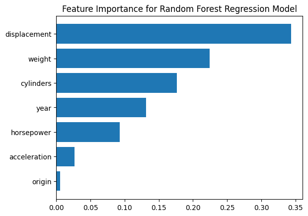

```python
rf_feature_imp = rf_model.feature_importances_
sorted_indices = rf_feature_imp.argsort()[::-1]
sorted_feature_names = [X.columns[i] for i in sorted_indices]
sorted_feat_imp = rf_feature_imp[sorted_indices]

plt.figure()
plt.barh(sorted_feature_names,sorted_feat_imp)
plt.title('Feature Importance for Random Forest Regression Model')
plt.gca().invert_yaxis()
plt.show()
```